# Project: TMDb movie data investigation

- Introduction
- Data Wrangling
- Exploratory Data Analysis
- Conclusions

## Introduction

> In this project we will be analyzing imdb movie data. The main focus of our investigation will be:
> 1. Which genres are most popular from 2005 to 2015 (for one decade)?
> 2. What is the relationship between a director and a genre and its effect on revenue?

```python
import numpy as np
import pandas as pd
import matplotlib.pyplot as plt
import seaborn as sns
% matplotlib inline
```

## Data Wrangling

```python
# Loading data
df = pd.read_csv('tmdb-movies.csv')
df.head()
```

|  | id | imdb_id | popularity | budget | revenue | original_title | cast | homepage | director | tagline | ... | overview | runtime | genres | production_companies | release_date | vote_count | vote_average | release_year | budget_adj | revenue_adj |
| --- | --- | --- | --- | --- | --- | --- | --- | --- | --- | --- | --- | --- | --- | --- | --- | --- | --- | --- | --- | --- | --- |
| 0 | 135397 | tt0369610 | 32.985763 | 150000000 | 1513528810 | Jurassic World | Chris Pratt\|Bryce Dallas Howard\|Irrfan Khan\|Vi... | http://www.jurassicworld.com/ | Colin Trevorrow | The park is open. | ... | Twenty-two years after the events of Jurassic ... | 124 | Action\|Adventure\|Science Fiction\|Thriller | Universal Studios\|Amblin Entertainment\|Legenda... | 6/9/15 | 5562 | 6.5 | 2015 | 1.379999e+08 | 1.392446e+09 |
| 1 | 76341 | tt1392190 | 28.419936 | 150000000 | 378436354 | Mad Max: Fury Road | Tom Hardy\|Charlize Theron\|Hugh Keays-Byrne\|Nic... | http://www.madmaxmovie.com/ | George Miller | What a Lovely Day. | ... | An apocalyptic story set in the furthest reach... | 120 | Action\|Adventure\|Science Fiction\|Thriller | Village Roadshow Pictures\|Kennedy Miller Produ... | 5/13/15 | 6185 | 7.1 | 2015 | 1.379999e+08 | 3.481613e+08 |
| 2 | 262500 | tt2908446 | 13.112507 | 110000000 | 295238201 | Insurgent | Shailene Woodley\|Theo James\|Kate Winslet\|Ansel... | http://www.thedivergentseries.movie/#insurgent | Robert Schwentke | One Choice Can Destroy You | ... | Beatrice Prior must confront her inner demons ... | 119 | Adventure\|Science Fiction\|Thriller | Summit Entertainment\|Mandeville Films\|Red Wago... | 3/18/15 | 2480 | 6.3 | 2015 | 1.012000e+08 | 2.716190e+08 |
| 3 | 140607 | tt2488496 | 11.173104 | 200000000 | 2068178225 | Star Wars: The Force Awakens | Harrison Ford\|Mark Hamill\|Carrie Fisher\|Adam D... | http://www.starwars.com/films/star-wars-episod... | J.J. Abrams | Every generation has a story. | ... | Thirty years after defeating the Galactic Empi... | 136 | Action\|Adventure\|Science Fiction\|Fantasy | Lucasfilm\|Truenorth Productions\|Bad Robot | 12/15/15 | 5292 | 7.5 | 2015 | 1.839999e+08 | 1.902723e+09 |
| 4 | 168259 | tt2820852 | 9.335014 | 190000000 | 1506249360 | Furious 7 | Vin Diesel\|Paul Walker\|Jason Statham\|Michelle ... | http://www.furious7.com/ | James Wan | Vengeance Hits Home | ... | Deckard Shaw seeks revenge against Dominic Tor... | 137 | Action\|Crime\|Thriller | Universal Pictures\|Original Film\|Media Rights ... | 4/1/15 | 2947 | 7.3 | 2015 | 1.747999e+08 | 1.385749e+09 |

5 rows × 21 columns

```python
df.info()
```

```
<class 'pandas.core.frame.DataFrame'>
RangeIndex: 10866 entries, 0 to 10865
Data columns (total 21 columns):
id                      10866 non-null int64
imdb_id                 10856 non-null object
popularity              10866 non-null float64
budget                  10866 non-null int64
revenue                 10866 non-null int64
original_title          10866 non-null object
cast                    10790 non-null object
homepage                2936 non-null object
director                10822 non-null object
tagline                 8042 non-null object
keywords                9373 non-null object
overview                10862 non-null object
runtime                 10866 non-null int64
genres                  10843 non-null object
production_companies    9836 non-null object
release_date            10866 non-null object
vote_count              10866 non-null int64
vote_average            10866 non-null float64
release_year            10866 non-null int64
budget_adj              10866 non-null float64
revenue_adj             10866 non-null float64
dtypes: float64(4), int64(6), object(11)
memory usage: 1.7+ MB
```

```python
# From the info from the last cell I have dropped id', 'imdb_id', 'budget', 'revenue', 'homepage', 'tagline', 'keywords',
# 'overview', 'runtime', 'production_companies' because these seem to be irrelevent for my investigation purposes
# I have dropped all nulls as well.

df.drop(['id', 'imdb_id', 'budget', 'revenue', 'homepage', 'tagline', 'keywords', 'overview', 'runtime', 'production_companies'], axis = 1, inplace = True)
```

```python
df.head()
```

|  | popularity | original_title | cast | director | genres | release_date | vote_count | vote_average | release_year | budget_adj | revenue_adj |
| --- | --- | --- | --- | --- | --- | --- | --- | --- | --- | --- | --- |
| 0 | 32.985763 | Jurassic World | Chris Pratt\|Bryce Dallas Howard\|Irrfan Khan\|Vi... | Colin Trevorrow | Action\|Adventure\|Science Fiction\|Thriller | 6/9/15 | 5562 | 6.5 | 2015 | 1.379999e+08 | 1.392446e+09 |
| 1 | 28.419936 | Mad Max: Fury Road | Tom Hardy\|Charlize Theron\|Hugh Keays-Byrne\|Nic... | George Miller | Action\|Adventure\|Science Fiction\|Thriller | 5/13/15 | 6185 | 7.1 | 2015 | 1.379999e+08 | 3.481613e+08 |
| 2 | 13.112507 | Insurgent | Shailene Woodley\|Theo James\|Kate Winslet\|Ansel... | Robert Schwentke | Adventure\|Science Fiction\|Thriller | 3/18/15 | 2480 | 6.3 | 2015 | 1.012000e+08 | 2.716190e+08 |
| 3 | 11.173104 | Star Wars: The Force Awakens | Harrison Ford\|Mark Hamill\|Carrie Fisher\|Adam D... | J.J. Abrams | Action\|Adventure\|Science Fiction\|Fantasy | 12/15/15 | 5292 | 7.5 | 2015 | 1.839999e+08 | 1.902723e+09 |
| 4 | 9.335014 | Furious 7 | Vin Diesel\|Paul Walker\|Jason Statham\|Michelle ... | James Wan | Action\|Crime\|Thriller | 4/1/15 | 2947 | 7.3 | 2015 | 1.747999e+08 | 1.385749e+09 |

```python
df.info()
```

```
<class 'pandas.core.frame.DataFrame'>
RangeIndex: 10866 entries, 0 to 10865
Data columns (total 11 columns):
popularity        10866 non-null float64
original_title    10866 non-null object
cast              10790 non-null object
director          10822 non-null object
genres            10843 non-null object
release_date      10866 non-null object
vote_count        10866 non-null int64
vote_average      10866 non-null float64
release_year      10866 non-null int64
budget_adj        10866 non-null float64
revenue_adj       10866 non-null float64
dtypes: float64(4), int64(2), object(5)
memory usage: 933.9+ KB
```

```python
df.dropna(inplace=True)
df.info()
```

```
<class 'pandas.core.frame.DataFrame'>
Int64Index: 10732 entries, 0 to 10865
Data columns (total 11 columns):
popularity        10732 non-null float64
original_title    10732 non-null object
cast              10732 non-null object
director          10732 non-null object
genres            10732 non-null object
release_date      10732 non-null object
vote_count        10732 non-null int64
vote_average      10732 non-null float64
release_year      10732 non-null int64
budget_adj        10732 non-null float64
revenue_adj       10732 non-null float64
dtypes: float64(4), int64(2), object(5)
memory usage: 1006.1+ KB
```

## Exploratory Data Analysis

### Research Question 1 (Which genres are most popular from 2005 to 2015 (for one decade)?)

```python
# Here I have defined a function which splits a row into many rows depending upon the number of delimiters for a perticular column

def split_df_list(df_to_modify, column_to_modify, delimiter):
    def splitlist_to_rows(row, row_coll, column_to_modify, delimiter):
        split_row = row[column_to_modify].split(delimiter)
        for sr in split_row:
            new_row = row.to_dict()
            new_row[column_to_modify] = sr
            row_coll.append(new_row)
    new_rows = []
    df_to_modify.apply(splitlist_to_rows, axis = 1, args=(new_rows, column_to_modify, delimiter))
    new_df = pd.DataFrame(new_rows)
    return new_df
# splitting genres
df_genre_split = split_df_list(df, 'genres', '|')
df_genre_split.head()
```

|  | budget_adj | cast | director | genres | original_title | popularity | release_date | release_year | revenue_adj | vote_average | vote_count |
| --- | --- | --- | --- | --- | --- | --- | --- | --- | --- | --- | --- |
| 0 | 1.379999e+08 | Chris Pratt\|Bryce Dallas Howard\|Irrfan Khan\|Vi... | Colin Trevorrow | Action | Jurassic World | 32.985763 | 6/9/15 | 2015 | 1.392446e+09 | 6.5 | 5562 |
| 1 | 1.379999e+08 | Chris Pratt\|Bryce Dallas Howard\|Irrfan Khan\|Vi... | Colin Trevorrow | Adventure | Jurassic World | 32.985763 | 6/9/15 | 2015 | 1.392446e+09 | 6.5 | 5562 |
| 2 | 1.379999e+08 | Chris Pratt\|Bryce Dallas Howard\|Irrfan Khan\|Vi... | Colin Trevorrow | Science Fiction | Jurassic World | 32.985763 | 6/9/15 | 2015 | 1.392446e+09 | 6.5 | 5562 |
| 3 | 1.379999e+08 | Chris Pratt\|Bryce Dallas Howard\|Irrfan Khan\|Vi... | Colin Trevorrow | Thriller | Jurassic World | 32.985763 | 6/9/15 | 2015 | 1.392446e+09 | 6.5 | 5562 |
| 4 | 1.379999e+08 | Tom Hardy\|Charlize Theron\|Hugh Keays-Byrne\|Nic... | George Miller | Action | Mad Max: Fury Road | 28.419936 | 5/13/15 | 2015 | 3.481613e+08 | 7.1 | 6185 |

```python
# creating array for unique genres

gen_arr = df_genre_split['genres'].unique()
gen_arr
```

```
array(['Action', 'Adventure', 'Science Fiction', 'Thriller', 'Fantasy',
       'Crime', 'Western', 'Drama', 'Family', 'Animation', 'Comedy',
       'Mystery', 'Romance', 'War', 'History', 'Music', 'Horror',
       'Documentary', 'TV Movie', 'Foreign'], dtype=object)
```

```python
# creating mask for a perticular date range (here 2005 - 2015)
mask = (df_genre_split['release_date'] >= '01/01/2005') & (df_genre_split['release_date'] <= '31/12/2015')
```

```python
df_genres_pop = pd.DataFrame()  # an empty dataframe is created which will hold genre and its average popularity over a date range
for i in gen_arr:
    df_genre_dated = df_genre_split[(df_genre_split['genres'] == i) & mask] # a dataframe for a perticular genre and date range
    sum_pop = df_genre_dated['popularity'].sum()/len(df_genre_dated) # average of popularity of a perticular genre over a date range
    df_genres_pop = df_genres_pop.append({'genres': i, 'avgPopularity' : sum_pop}, ignore_index=True) # appending these to the new dataframe
print(df_genres_pop)
```

```
    avgPopularity           genres
0        0.855610           Action
1        1.126964        Adventure
2        0.886484  Science Fiction
3        0.707233         Thriller
4        1.019025          Fantasy
5        0.763822            Crime
6        0.744377          Western
7        0.611561            Drama
8        0.817479           Family
9        0.878756        Animation
10       0.577084           Comedy
11       0.655626          Mystery
12       0.581374          Romance
13       0.847899              War
14       0.635719          History
15       0.536324            Music
16       0.460525           Horror
17       0.177141      Documentary
18       0.278697         TV Movie
19       0.174851          Foreign
```

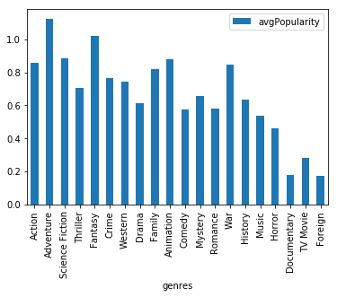

```python
# Here I have created a bar plot for popularity vs genres over the latest decade available (2005 - 2015)
df_genres_pop.plot(x = 'genres', y = 'avgPopularity', kind = 'bar');
```